# Lesson 19: Inference for Several Proportions, Goodness-of-Fit, and Independence

Homework

- Word Document
- PDF Document

## Solutions

**Please note that the steps show rounded numbers, but that the final answers to the problems are calculated without rounding.**

Problem

Part

Solution

1

-

The requirements are met because all expected counts are greater than or equal to five

2

-

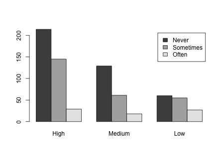

3

-

$H_0: \text{Religiosity and frequency of anger are independent}$  
$H_a: \text{Religiosity and frequency of anger are not independent}$

4

-

$\chi^2 = 23.474$  
$df = 4$

5

-

$\text{P-value} = 0.0001$

6

-

reject the null hypothesis

7

-

There is sufficient evidence to suggest that religiosity and frequency of anger at something beyond one’s control are not independent.

8

-

The requirements are met because all expected counts are greater than or equal to five

9

-

[figure not shown]

10

-

$H_0: \text{Family structure and whether a girl goes to college are independent}$  
$H_a: \text{Family structure and whether a girl goes to college are not independent}$

11

-

$\chi^2 = 10.357$  
$df = 3$

12

-

$\text{P-value} = 0.016$

13

-

reject the null hypothesis

14

-

There is sufficient evidence to suggest that family structure and whether a girl goes to college are not independent

15

-

The requirements are met because all expected counts are greater than or equal to five

16

-

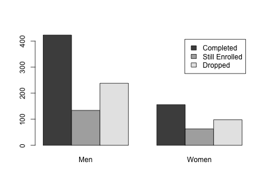

17

-

$H_0: \text{Gender and PhD status are independent}$  
$H_a: \text{Gender and PhD status are not independent.}$

18

-

$\chi^2 = 1.932$  
$df = 2$

19

-

$\text{P-value} = 0.381$

20

-

fail to reject the null hypothesis

21

-

There is insufficient evidence to conclude that a student’s gender and status in a PhD program are not independent.